# **Spatial Transcriptomics Deep Learning (STDL) Project Notebook**

> The notebook contains main experiments and examples of how to use the code

## **Phase 1: Pre-processing and technical preparations**

### 1.1: **Assign GPU device and allow CUDA debugging**

```python
# create code to reimport module if i change it
%load_ext autoreload
```

```python
# the next 2 lines are to allow debugging with CUDA !
import os
os.environ['CUDA_LAUNCH_BLOCKING'] = "1"
print(f'cuda debugging allowed')
```

```
cuda debugging allowed
```

```python
%%time

import torch
print(f'cuda device count: {torch.cuda.device_count()}')
device = torch.device('cuda' if torch.cuda.is_available() else 'cpu')
print('Using device:', device)
#Additional Info when using cuda
if device.type == 'cuda':
    print(f'device name: {torch.cuda.get_device_name(0)}')
    print(f'torch.cuda.device(0): {torch.cuda.device(0)}')
    print('Memory Usage:')
    print('Allocated:', round(torch.cuda.memory_allocated(0)/1024**3,1), 'GB')
    print('Cached:   ', round(torch.cuda.memory_cached(0)/1024**3,1), 'GB')
# NOTE: important !!!!!!
# clearing out the cache before beginning
torch.cuda.empty_cache()
```

```
cuda device count: 1
Using device: cuda
device name: GeForce GTX 1080 Ti
torch.cuda.device(0): <torch.cuda.device object at 0x7f750ce01ad0>
Memory Usage:
Allocated: 0.0 GB
Cached:    0.0 GB
CPU times: user 1.67 s, sys: 6.36 s, total: 8.03 s
Wall time: 11.4 s
```

### 1.2: **Import the Pre-Process module**

> `loadAndPreProcess` module contains methods to load the data files as pytorch and pandas objects, methods to preprocess the given data, and methods to create custom datasets from the preprocessed data.

```python
# note: path to project is: /home/roy.rubin/STDLproject/
%autoreload 2
import loadAndPreProcess
```

### 1.3: **Load pytorch dataset objects from the image folder**

> loading regular and augmented datasets created from the given image folder with transformations.

> Note: `augmentedImageFolder` is a custom dataset of imageFolder objects with different transformations (see code).

```python
im_hight_and_width_size = 176  # values: 176 (doesnt work with inception) / 224 (doesnt work with inception) / 299 (works with inception)
```

```python
%%time

path_to_images_dir_patient1_train = "/home/roy.rubin/STDLproject/spatialGeneExpressionData/patient1/images"
imageFolder_train = loadAndPreProcess.load_dataset_from_images_folder(path_to_images_dir_patient1_train, im_hight_and_width_size)
augmentedImageFolder_train = loadAndPreProcess.load_augmented_imageFolder_DS_from_images_folder(path_to_images_dir_patient1_train, im_hight_and_width_size)
```

```
----- entered function load_dataset_from_pictures_folder -----

----- finished function load_dataset_from_pictures_folder -----


----- entered function load_dataset_from_pictures_folder -----

----- finished function load_dataset_from_pictures_folder -----

CPU times: user 368 ms, sys: 138 ms, total: 506 ms
Wall time: 1.53 s
```

```python
%%time

path_to_images_dir_patient2_test = "/home/roy.rubin/STDLproject/spatialGeneExpressionData/patient2/images"
imageFolder_test = loadAndPreProcess.load_dataset_from_images_folder(path_to_images_dir_patient2_test, im_hight_and_width_size)
# augmentedImageFolder_test = loadAndPreProcess.load_augmented_imageFolder_DS_from_images_folder(path_to_images_dir_patient2_test, im_hight_and_width_size) # not needed for now
```

```
----- entered function load_dataset_from_pictures_folder -----

----- finished function load_dataset_from_pictures_folder -----

CPU times: user 35.7 ms, sys: 163 ms, total: 199 ms
Wall time: 982 ms
```

### 1.4: **Load pandas dataframe objects from the given mtx/tsv/csv files**

> `matrix_dataframe` represents the gene expression count values of each sample for each gene

> `features_dataframe` contains the names of all the genes

> `barcodes_dataframe` contains the names of all the samples

```python
%%time

path_to_mtx_tsv_files_dir_patient1_train = "/home/roy.rubin/STDLproject/spatialGeneExpressionData/patient1"
matrix_dataframe_train, features_dataframe_train , barcodes_dataframe_train = loadAndPreProcess.load_dataframes_from_mtx_and_tsv_new(path_to_mtx_tsv_files_dir_patient1_train)
```

```
----- entered function load_dataframes_from_mtx_and_tsv -----
started reading features.tsv
V  finished reading features.tsv
started reading barcodes.tsv
V  finished reading barcodes.tsv
started reading matrix.mtx. this might take some time ...
V  finished reading matrix.mtx
adjusting matrix_dataframe
V  finished working on matrix_dataframe

----- finished function load_dataframes_from_mtx_and_tsv -----

CPU times: user 1min 38s, sys: 4.62 s, total: 1min 42s
Wall time: 1min 44s
```

```python
%%time

path_to_mtx_tsv_files_dir_patient2_test = "/home/roy.rubin/STDLproject/spatialGeneExpressionData/patient2"
matrix_dataframe_test, features_dataframe_test , barcodes_dataframe_test = loadAndPreProcess.load_dataframes_from_mtx_and_tsv_new(path_to_mtx_tsv_files_dir_patient2_test)
```

```
----- entered function load_dataframes_from_mtx_and_tsv -----
started reading features.tsv
V  finished reading features.tsv
started reading barcodes.tsv
V  finished reading barcodes.tsv
started reading matrix.mtx. this might take some time ...
V  finished reading matrix.mtx
adjusting matrix_dataframe
V  finished working on matrix_dataframe

----- finished function load_dataframes_from_mtx_and_tsv -----

CPU times: user 1min 29s, sys: 3.73 s, total: 1min 32s
Wall time: 1min 34s
```

### 1.5: **Remove samples from the matrix dataframe with no matching images in the image folder**

> Note: indices are being reset after this action, so a mapping of old to new column indices is returned: `column_mapping`.

> Note: the dataframe is also reordered according to the images order in the image folder

```python
%%time

matrix_dataframe_train, column_mapping_train = loadAndPreProcess.cut_samples_with_no_matching_image_and_reorder_df(matrix_df=matrix_dataframe_train,
                                                                                                                    image_folder_of_the_df=imageFolder_train,
                                                                                                                    barcodes_df=barcodes_dataframe_train)
```

```
cutting samples that dont have mathching images in the image folder from the dataframe ...
V   done :)

CPU times: user 38.9 s, sys: 21.9 s, total: 1min
Wall time: 1min 1s
```

```python
%%time

matrix_dataframe_test, column_mapping_test = loadAndPreProcess.cut_samples_with_no_matching_image_and_reorder_df(matrix_df=matrix_dataframe_test,
                                                                                                                  image_folder_of_the_df=imageFolder_test,
                                                                                                                  barcodes_df=barcodes_dataframe_test)
```

```
cutting samples that dont have mathching images in the image folder from the dataframe ...
V   done :)

CPU times: user 39.8 s, sys: 16.1 s, total: 55.9 s
Wall time: 56.5 s
```

### 1.6: **Remove less-informative genes**

> we define *less-informative* genes as genes with less than K counts over all samples

> `Base_value` is a parameter for the user's choice

> Note: indices are being reset after this action, so a mapping of old to new column indices is returned: `row_mapping`.

```python
%%time

# begin by asserting that our dataframes have the same genes to begin with using the metadata of features_dataframe
assert features_dataframe_train['gene_names'].equals(features_dataframe_test['gene_names'])

Base_value = 10
matrix_dataframe_train, matrix_dataframe_test, row_mapping = loadAndPreProcess.cut_genes_with_under_B_counts_from_train_and_test(matrix_dataframe_train, matrix_dataframe_test, Base_value)
```

```
checking for genes (rows) that contain less than B counts in both dataframes ...
discarding relevant rows ...
CPU times: user 48.3 s, sys: 25.7 s, total: 1min 14s
Wall time: 1min 14s
```

### 1.7: **Normalize matrix_dataframe entries**

> normaliztion will be performed on the remainning rows of the dataframe with the logic "log 1P"

> This method Calculates log(1 + x)

```python
%%time

matrix_dataframe_train = loadAndPreProcess.perform_log_1p_normalization(matrix_dataframe_train)
```

```
performing log1P transformation of the dataframe ...

CPU times: user 1.74 s, sys: 68.8 ms, total: 1.81 s
Wall time: 1.82 s
```

```python
%%time

matrix_dataframe_test = loadAndPreProcess.perform_log_1p_normalization(matrix_dataframe_test)
```

```
performing log1P transformation of the dataframe ...

CPU times: user 2.05 s, sys: 16 ms, total: 2.06 s
Wall time: 2.07 s
```

> We have performed all of the pre-processing actions on our matrix dataframes. (more pre-processing is still needed our datasets)

> print some information regarding our dataframes

```python
import projectUtilities
projectUtilities.printInfoAboutReducedDF(matrix_dataframe_train)
print("\n****\n")
projectUtilities.printInfoAboutReducedDF(matrix_dataframe_test)
```

```
print data regarding the reduced dataframe:
<class 'pandas.core.frame.DataFrame'>
RangeIndex: 18077 entries, 0 to 18076
Columns: 3813 entries, 0 to 3812
dtypes: Sparse[float64, 0.0](3813)
memory usage: 220.7 MB
None
   0         1     2     3     4         5     6     7         8     9     \
0   0.0  0.000000   0.0   0.0   0.0  0.693147   0.0   0.0  0.000000   0.0
1   0.0  1.098612   0.0   0.0   0.0  0.000000   0.0   0.0  0.693147   0.0
2   0.0  0.000000   0.0   0.0   0.0  0.000000   0.0   0.0  0.000000   0.0
3   0.0  0.000000   0.0   0.0   0.0  0.000000   0.0   0.0  0.000000   0.0
4   0.0  0.693147   0.0   0.0   0.0  0.000000   0.0   0.0  0.000000   0.0

   ...  3803  3804      3805  3806  3807  3808  3809  3810  3811  3812
0  ...   0.0   0.0  0.000000   0.0   0.0   0.0   0.0   0.0   0.0   0.0
1  ...   0.0   0.0  0.000000   0.0   0.0   0.0   0.0   0.0   0.0   0.0
2  ...   0.0   0.0  0.000000   0.0   0.0   0.0   0.0   0.0   0.0   0.0
3  ...   0.0   0.0  0.000000   0.0   0.0   0.0   0.0   0.0   0.0   0.0
4  ...   0.0   0.0  0.693147   0.0   0.0   0.0   0.0   0.0   0.0   0.0

[5 rows x 3813 columns]

min value in matrix_dataframe 0.0 max value in matrix_dataframe 8.62748154531036

median value in matrix_dataframe 0.0 mean value in matrix_dataframe 0.32039982441271264

number of different values in matrix_dataframe is  1087

list of 10 most common values in matrix_dataframe is:
1: the value 0.0 appeared 49638925 times (constitutes 72.01603% of the matrix values)
2: the value 0.6931471805599453 appeared 9701765 times (constitutes 14.07530% of the matrix values)
3: the value 1.0986122886681096 appeared 3828178 times (constitutes 5.55391% of the matrix values)
4: the value 1.3862943611198906 appeared 1865714 times (constitutes 2.70677% of the matrix values)
5: the value 1.6094379124341003 appeared 1038719 times (constitutes 1.50697% of the matrix values)
6: the value 1.791759469228055 appeared 636707 times (constitutes 0.92373% of the matrix values)
7: the value 1.9459101490553132 appeared 420712 times (constitutes 0.61037% of the matrix values)
8: the value 2.0794415416798357 appeared 294745 times (constitutes 0.42762% of the matrix values)
9: the value 2.1972245773362196 appeared 215889 times (constitutes 0.31321% of the matrix values)
10: the value 2.302585092994046 appeared 164262 times (constitutes 0.23831% of the matrix values)
```

[output cut: 29 more lines]

```
median value in matrix_dataframe 0.0 mean value in matrix_dataframe 0.315108124458449

number of different values in matrix_dataframe is  1172

list of 10 most common values in matrix_dataframe is:
1: the value 0.0 appeared 52511911 times (constitutes 72.35123% of the matrix values)
2: the value 0.6931471805599453 appeared 10229677 times (constitutes 14.09451% of the matrix values)
3: the value 1.0986122886681096 appeared 3962322 times (constitutes 5.45931% of the matrix values)
4: the value 1.3862943611198906 appeared 1903778 times (constitutes 2.62304% of the matrix values)
5: the value 1.6094379124341003 appeared 1049475 times (constitutes 1.44597% of the matrix values)
6: the value 1.791759469228055 appeared 641942 times (constitutes 0.88447% of the matrix values)
7: the value 1.9459101490553132 appeared 424204 times (constitutes 0.58447% of the matrix values)
8: the value 2.0794415416798357 appeared 297671 times (constitutes 0.41013% of the matrix values)
9: the value 2.1972245773362196 appeared 217997 times (constitutes 0.30036% of the matrix values)
10: the value 2.302585092994046 appeared 167120 times (constitutes 0.23026% of the matrix values)
```

### 1.8: **Create custom datasets**

> Each custom dataset is tailored per task

> there are four tasks: single gene prediction, k gene prediction, all gene prediction using NMF dim. reduction, all gene prediction using AE dim. reduction

> > A Dataset created from the TRAIN data WITH augmentation (with image transformations)

> > A Dataset created from the TEST data WITHOUT augmentation (without image transformations)

```python
%%time

## choose gene
gene_name = 'CRISP3'  # was changed from 'BRCA1' because CRISP3 has the (almost) highest variance in both the train and test datasets.
                      # NOTE: the gene 'CRISP3' is "upregulated in certain types of prostate cancer" according to
                      #       https://www.genecards.org/cgi-bin/carddisp.pl?gene=CRISP3&keywords=rich
from projectUtilities import get_variance_of_gene
gene_variance_value = get_variance_of_gene(gene_name=gene_name, matrix_df=matrix_dataframe_train, row_mapping=row_mapping, features_df=features_dataframe_train)
print(f'The chosen gene is {gene_name} and its variance is {gene_variance_value}')

## create datasets
custom_DS_SingleValuePerImg_augmented = loadAndPreProcess.STDL_Dataset_SingleValuePerImg(imageFolder=augmentedImageFolder_train,
                                                               matrix_dataframe=matrix_dataframe_train,
                                                               features_dataframe=features_dataframe_train,
                                                               barcodes_dataframe=barcodes_dataframe_train,
                                                               column_mapping=column_mapping_train,
                                                               row_mapping=row_mapping,
                                                               chosen_gene_name=gene_name)
custom_DS_SingleValuePerImg_test = loadAndPreProcess.STDL_Dataset_SingleValuePerImg(imageFolder=imageFolder_test,
                                                               matrix_dataframe=matrix_dataframe_test,
                                                               features_dataframe=features_dataframe_test,
                                                               barcodes_dataframe=barcodes_dataframe_test,
                                                               column_mapping=column_mapping_test,
                                                               row_mapping=row_mapping,
                                                               chosen_gene_name=gene_name)
```

```
The chosen gene is CRISP3 and its variance is 1.3530372139065492

----- entering __init__ phase of  STDL_Dataset_SingleValuePerImg -----

----- finished __init__ phase of  STDL_Dataset_SingleValuePerImg -----


----- entering __init__ phase of  STDL_Dataset_SingleValuePerImg -----

----- finished __init__ phase of  STDL_Dataset_SingleValuePerImg -----

CPU times: user 893 ms, sys: 75.2 ms, total: 968 ms
Wall time: 966 ms
```

**Note:** inside the init phase of `STDL_Dataset_KValuesPerImg_KGenesWithHighestVariance` class, K genes with the highest variance are chosen from matrix_dataframe, and they are the only genes that are kept for training and testing purposes

```python
%%time

k = 10

custom_DS_KGenesWithHighestVariance_augmented = loadAndPreProcess.STDL_Dataset_KValuesPerImg_KGenesWithHighestVariance(imageFolder=augmentedImageFolder_train,
                                                                           matrix_dataframe=matrix_dataframe_train,
                                                                           features_dataframe=features_dataframe_train,
                                                                           barcodes_dataframe=barcodes_dataframe_train,
                                                                           column_mapping=column_mapping_train,
                                                                           row_mapping=row_mapping,
                                                                           num_of_dims_k=k)
custom_DS_KGenesWithHighestVariance_test = loadAndPreProcess.STDL_Dataset_KValuesPerImg_KGenesWithHighestVariance(imageFolder=imageFolder_test,
                                                                           matrix_dataframe=matrix_dataframe_test,
                                                                           features_dataframe=features_dataframe_test,
                                                                           barcodes_dataframe=barcodes_dataframe_test,
                                                                           column_mapping=column_mapping_test,
                                                                           row_mapping=row_mapping,
                                                                           num_of_dims_k=k)
```

```
----- entering __init__ phase of  STDL_Dataset_KValuesPerImg_KGenesWithHighestVariance -----
calculate variance of all columns from  matrix_dataframe - and choosing K genes with higest variance ...
the K genes with the highest variance are:
      gene_names  variance
15326      COX6C  1.384259
10975     CRISP3  1.353037
6665        CPB1  1.328052
20428        MGP  1.309196
13994     TCEAL4  1.237330
9549      CXCL14  1.215041
5098      IGFBP5  1.177371
18155      CCND1  1.167686
11978       AGR2  1.163414
20840       KRT8  1.158179

----- finished __init__ phase of  STDL_Dataset_LatentTensor -----


----- entering __init__ phase of  STDL_Dataset_KValuesPerImg_KGenesWithHighestVariance -----
calculate variance of all columns from  matrix_dataframe - and choosing K genes with higest variance ...
the K genes with the highest variance are:
      gene_names  variance
10975     CRISP3  1.301761
6665        CPB1  1.259807
9549      CXCL14  1.217983
32395      IGLC2  1.125526
4026        IGKC  1.107278
20428        MGP  1.096459
23764      IGHG1  0.993734
23765      IGHG3  0.987250
13994     TCEAL4  0.985546
11978       AGR2  0.955655

----- finished __init__ phase of  STDL_Dataset_LatentTensor -----

CPU times: user 17.8 s, sys: 29.2 s, total: 47 s
Wall time: 47.5 s
```

**Note:** inside the init phase of `STDL_Dataset_KValuesPerImg_LatentTensor_NMF` class, an NMF decompositionis performed on the matrix_dataframe object

```python
%%time

k = 10

custom_DS_LatentTensor_NMF_augmented = loadAndPreProcess.STDL_Dataset_KValuesPerImg_LatentTensor_NMF(imageFolder=augmentedImageFolder_train,
                                                                           matrix_dataframe=matrix_dataframe_train,
                                                                           features_dataframe=features_dataframe_train,
                                                                           barcodes_dataframe=barcodes_dataframe_train,
                                                                           column_mapping=column_mapping_train,
                                                                           num_of_dims_k=k)
custom_DS_LatentTensor_NMF_test = loadAndPreProcess.STDL_Dataset_KValuesPerImg_LatentTensor_NMF(imageFolder=imageFolder_test,
                                                                           matrix_dataframe=matrix_dataframe_test,
                                                                           features_dataframe=features_dataframe_test,
                                                                           barcodes_dataframe=barcodes_dataframe_test,
                                                                           column_mapping=column_mapping_test,
                                                                           num_of_dims_k=k)
```

```
----- entering __init__ phase of  STDL_Dataset_KValuesPerImg_LatentTensor_NMF -----
performing NMF decomposition on main matrix dataframe ...

----- finished __init__ phase of  STDL_Dataset_LatentTensor -----


----- entering __init__ phase of  STDL_Dataset_KValuesPerImg_LatentTensor_NMF -----
performing NMF decomposition on main matrix dataframe ...

----- finished __init__ phase of  STDL_Dataset_LatentTensor -----

CPU times: user 16min 14s, sys: 8min 33s, total: 24min 48s
Wall time: 59 s
```

**Note:**

- first we create a dataset from `matrix_dataframe_train` to feed our AEnet.
- Then we create our AEnet and train it.
- Finally, we create our `custom_DS_LatentTensor_AE` class, in which the Autoencoder network will be saved.

```python
dataset_from_matrix_df = loadAndPreProcess.STDL_Dataset_matrix_df_for_AE_init(matrix_dataframe_train)
```

```python
%%time

from executionModule import get_Trained_AEnet
k = 10
AEnet = get_Trained_AEnet(dataset_from_matrix_df=dataset_from_matrix_df, z_dim=k, num_of_epochs=10, device=device)
```

```
----- entered function return_trained_AE_net -----
note - number of (hidden) linear layers is supposed to be 3

entered __init__ of AutoencoderNet
****** begin training ******

iteration 1 of 10 epochs
batch 3813 of 3813 batches
finished inner loop.

in this epoch: min loss 0.012195979245007038 max loss 1.0647941827774048
               average loss 0.1136923164242589

iteration 2 of 10 epochs
batch 3813 of 3813 batches
finished inner loop.

in this epoch: min loss 0.011790989898145199 max loss 0.24099788069725037
               average loss 0.10556545838031701

iteration 3 of 10 epochs
batch 3813 of 3813 batches
finished inner loop.

in this epoch: min loss 0.011957711540162563 max loss 0.2137671858072281
               average loss 0.10400688352218153

iteration 4 of 10 epochs
batch 3813 of 3813 batches
finished inner loop.

in this epoch: min loss 0.01138342171907425 max loss 0.19253981113433838
               average loss 0.10324725908990055

iteration 5 of 10 epochs
batch 3813 of 3813 batches
finished inner loop.

in this epoch: min loss 0.010776101611554623 max loss 0.18074993789196014
               average loss 0.10259955243856973
```

[output cut: 25 more lines]

```

in this epoch: min loss 0.010269329883158207 max loss 0.16990186274051666
               average loss 0.10094930976165184

iteration 10 of 10 epochs
batch 3813 of 3813 batches
finished inner loop.

in this epoch: min loss 0.010146640241146088 max loss 0.16203002631664276
               average loss 0.10061477505402391

----- finished function return_trained_AE_net -----

CPU times: user 13min 20s, sys: 1min 37s, total: 14min 58s
Wall time: 15min 42s
```

```python
%%time

k = 10

custom_DS_LatentTensor_AE_augmented = loadAndPreProcess.STDL_Dataset_KValuesPerImg_LatentTensor_AutoEncoder(imageFolder=augmentedImageFolder_train,
                                                                           matrix_dataframe=matrix_dataframe_train,
                                                                           features_dataframe=features_dataframe_train,
                                                                           barcodes_dataframe=barcodes_dataframe_train,
                                                                           AEnet=AEnet,
                                                                           column_mapping=column_mapping_train,
                                                                           num_of_dims_k=k,
                                                                           device=device)
custom_DS_LatentTensor_AE_test = loadAndPreProcess.STDL_Dataset_KValuesPerImg_LatentTensor_AutoEncoder(imageFolder=imageFolder_test,
                                                                           matrix_dataframe=matrix_dataframe_test,
                                                                           features_dataframe=features_dataframe_test,
                                                                           barcodes_dataframe=barcodes_dataframe_test,
                                                                           AEnet=AEnet,
                                                                           column_mapping=column_mapping_test,
                                                                           num_of_dims_k=k,
                                                                           device=device)
```

```
----- entering __init__ phase of  STDL_Dataset_KValuesPerImg_LatentTensor_AutoEncoder -----
initializing the autoencoder (this might take a while) ...

----- finished __init__ phase of  STDL_Dataset_KValuesPerImg_LatentTensor_AutoEncoder -----


----- entering __init__ phase of  STDL_Dataset_KValuesPerImg_LatentTensor_AutoEncoder -----
initializing the autoencoder (this might take a while) ...

----- finished __init__ phase of  STDL_Dataset_KValuesPerImg_LatentTensor_AutoEncoder -----

CPU times: user 1.56 s, sys: 34.4 s, total: 36 s
Wall time: 36.7 s
```

### 1.9: prepare for the next phases in which the experiments are executed

> import `executionModule` which contains the experiments, training methods, and testing methods

> create `hyperparameters` dictionary which will contain all of the hyper-parameters for our experiments (note - user can change these later)

> > `BasicConvNet` model

> > `DensetNet121` model

**Warning:** change the hyper-parameters below with caution if needed !

```python
%autoreload 2
import executionModule

# define hyperparameters for the TRAINING of the models (NOT the testing phases of the experiments)
hyperparameters = dict()
hyperparameters['batch_size'] = 25
hyperparameters['max_alowed_number_of_batches'] = 99999 #<--------------------------change to inf or 99999. anythin below 1220 will cut some batches ... this is only used to speed up training
hyperparameters['precent_of_dataset_allocated_for_training'] = 0.8
hyperparameters['learning_rate'] = 1e-4
hyperparameters['momentum'] = 0.9
hyperparameters['num_of_epochs'] = 10 #<------------------------------------------change to 5 at least

# define hyperparameters for BsicConvNet
hyperparameters['channels'] = [32, 32, 64, 64]
hyperparameters['num_of_convolution_layers'] = len(hyperparameters['channels'])
hyperparameters['hidden_dims'] = [100, 100]
hyperparameters['num_of_hidden_layers'] = len(hyperparameters['hidden_dims'])
hyperparameters['pool_every'] = 99999

# list of all models used
model_list = []
model_list.append('BasicConvNet')
model_list.append('DensetNet121')
```

> Creating an assisting method for our testing that will time each experiment

> Also, we add the code before the plots to show them correctly `%matplotlib inline`

```python
%matplotlib inline

def experiment_loop(ds_train, ds_test, phase_name):
    for model_name in model_list:
        print(f'\nstarting experiment **{model_name}**\n')
        %time executionModule.runExperiment(ds_train=ds_train, ds_test=ds_test, hyperparams=hyperparameters, device=device, model_name=model_name, dataset_name=phase_name)
        print(f'\nfinished experiment {model_name}')
```

**Note:** In each experiment, the model is trained with the augmented train dataset, and then tested on the test dataset (NMF and AE experiments also test on the regular train dataset after training is done)

## Phase 2: Single Gene Prediction

```python
# experiment_loop(ds_train=custom_DS_SingleValuePerImg_augmented ,ds_test=custom_DS_SingleValuePerImg_test ,phase_name='single_gene_augmented')
```

```
----- entered function runExperiment -----
/ * \ ENTERED train_prediction_model / * \
****** begin training ******

iteration 1 of 10 epochs
batch 1221 of 1221 batches
finished inner loop.
in this epoch: average loss 2.9891782911901683

iteration 2 of 10 epochs
batch 1221 of 1221 batches
finished inner loop.
in this epoch: average loss 0.7066312523697557

iteration 3 of 10 epochs
batch 1221 of 1221 batches
finished inner loop.
in this epoch: average loss 0.5158275087637847

iteration 4 of 10 epochs
batch 1221 of 1221 batches
finished inner loop.
in this epoch: average loss 0.33947624312523056

iteration 5 of 10 epochs
batch 1221 of 1221 batches
finished inner loop.
in this epoch: average loss 0.148999274728925

iteration 6 of 10 epochs
batch 1221 of 1221 batches
finished inner loop.
in this epoch: average loss 0.13303095374155688

iteration 7 of 10 epochs
batch 1221 of 1221 batches
finished inner loop.
in this epoch: average loss 0.11125131968613242

iteration 8 of 10 epochs
```

[output cut: 25 more lines]

```
...        ...       ...
4010  1.386294  1.263436
4011  0.693147  0.411815
4012  0.000000  0.902421
4013  0.693147  2.524743
4014  0.000000  0.724822

[4015 rows x 2 columns]

----- finished function getSingleDimPrediction -----
distance between M_truth, M_pred: 74.99644237768474
distance between M_truth, Baseline: 72.28603324093415
distance between M_pred, Baseline: 31.472720874678334

----- entered function plot_Single_Gene_PredAndTrue -----
```

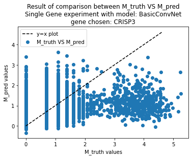

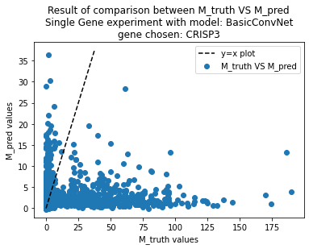

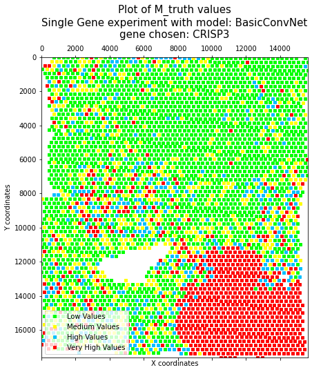

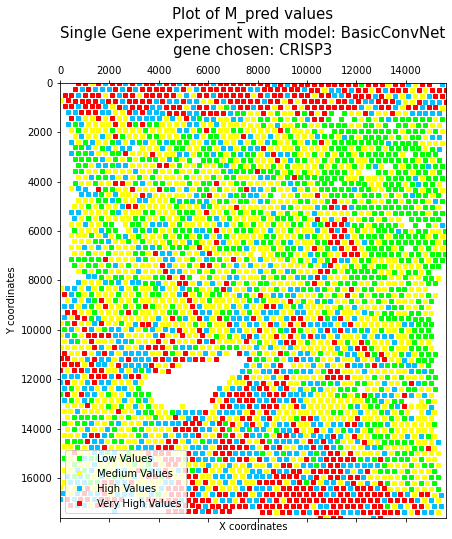

```
----- finished function plot_Single_Gene_PredAndTrue -----

----- finished function runExperiment -----
CPU times: user 39min 35s, sys: 7min 30s, total: 47min 6s
Wall time: 59min 33s
```

```python
%%time

executionModule.runExperiment(ds_train=custom_DS_SingleValuePerImg_augmented,
                                ds_test=custom_DS_SingleValuePerImg_test,
                                hyperparams=hyperparameters,
                                device=device,
                                model_name='BasicConvNet',
                                dataset_name='single_gene_augmented')
```

```
----- entered function runExperiment -----
/ * \ ENTERED train_prediction_model / * \
****** begin training ******

iteration 1 of 10 epochs
batch 1221 of 1221 batches
finished inner loop.
in this epoch: average loss 1.0197739206944012

iteration 2 of 10 epochs
batch 1221 of 1221 batches
finished inner loop.
in this epoch: average loss 0.8520237647979402

iteration 3 of 10 epochs
batch 1221 of 1221 batches
finished inner loop.
in this epoch: average loss 0.7676727922845336

iteration 4 of 10 epochs
batch 1221 of 1221 batches
finished inner loop.
in this epoch: average loss 0.7098465247734173

iteration 5 of 10 epochs
batch 1221 of 1221 batches
finished inner loop.
in this epoch: average loss 0.6710438582982127

iteration 6 of 10 epochs
batch 1221 of 1221 batches
finished inner loop.
in this epoch: average loss 0.6284034970497909

iteration 7 of 10 epochs
batch 1221 of 1221 batches
finished inner loop.
in this epoch: average loss 0.6089390356651981

iteration 8 of 10 epochs
```

[output cut: 25 more lines]

```
...        ...       ...
4010  1.386294  1.853618
4011  0.693147  1.039060
4012  0.000000  0.911343
4013  0.693147  2.467003
4014  0.000000  1.008303

[4015 rows x 2 columns]

----- finished function getSingleDimPrediction -----
distance between M_truth, M_pred: 73.30434271659222
distance between M_truth, Baseline: 72.28603324093415
distance between M_pred, Baseline: 39.808688496677746

----- entered function plot_Single_Gene_PredAndTrue -----
```

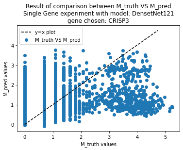

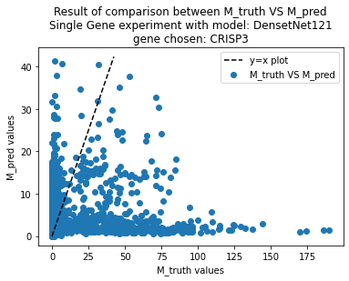

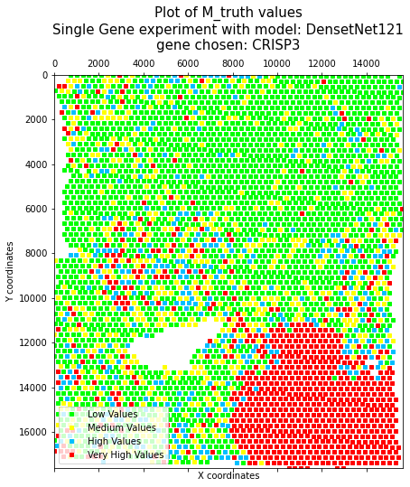

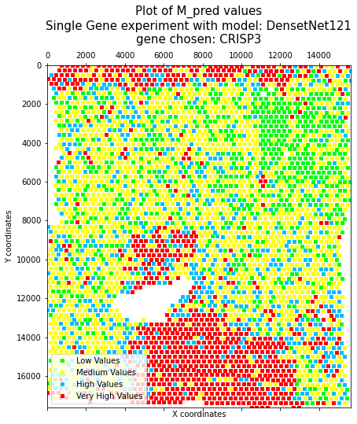

```
----- finished function plot_Single_Gene_PredAndTrue -----

----- finished function runExperiment -----
CPU times: user 1h 26min, sys: 7min 41s, total: 1h 33min 42s
Wall time: 1h 59min 31s
```

```python
%%time

executionModule.runExperiment(ds_train=custom_DS_SingleValuePerImg_augmented,
                                ds_test=custom_DS_SingleValuePerImg_test,
                                hyperparams=hyperparameters,
                                device=device,
                                model_name='DensetNet121',
                                dataset_name='single_gene_augmented')
```

## Phase 3: K genes prediction

```python
# experiment_loop(ds_train=custom_DS_KGenesWithHighestVariance_augmented ,ds_test=custom_DS_KGenesWithHighestVariance_test ,phase_name='k_genes_augmented')
```

```python
%%time

executionModule.runExperiment(ds_train=custom_DS_KGenesWithHighestVariance_augmented,
                                ds_test=custom_DS_KGenesWithHighestVariance_test,
                                hyperparams=hyperparameters,
                                device=device,
                                model_name='BasicConvNet',
                                dataset_name='k_genes_augmented')
```

```
----- entered function runExperiment -----
/ * \ ENTERED train_prediction_model / * \
****** begin training ******

iteration 1 of 10 epochs
batch 1221 of 1221 batches
finished inner loop.
in this epoch: average loss 1.4527373917272695

iteration 2 of 10 epochs
batch 1221 of 1221 batches
finished inner loop.
in this epoch: average loss 0.6066428094028352

iteration 3 of 10 epochs
batch 1221 of 1221 batches
finished inner loop.
in this epoch: average loss 0.41354497923019184

iteration 4 of 10 epochs
batch 1221 of 1221 batches
finished inner loop.
in this epoch: average loss 0.28986543408434085

iteration 5 of 10 epochs
batch 1221 of 1221 batches
finished inner loop.
in this epoch: average loss 0.21572316410500528

iteration 6 of 10 epochs
batch 1221 of 1221 batches
finished inner loop.
in this epoch: average loss 0.1852150254811936

iteration 7 of 10 epochs
batch 1221 of 1221 batches
finished inner loop.
in this epoch: average loss 0.1609865926041357

iteration 8 of 10 epochs
```

[output cut: 12 more lines]

```
in this epoch: average loss 0.13146983982841076
finished all epochs !
which means, that this model is now trained.
 \ * / FINISHED train_prediction_model \ * /

----- entered function getKDimPrediction -----
batch 201 of 201 batches
----- finished function getKDimPrediction -----
distance between M_truth, M_pred: 448.41151281926574
distance between M_truth, Baseline: 261.825453347885
distance between M_pred, Baseline: 308.73612961355457

----- finished function runExperiment -----
CPU times: user 42min 2s, sys: 6min, total: 48min 3s
Wall time: 1h 8min 53s
```

```python
%%time

executionModule.runExperiment(ds_train=custom_DS_KGenesWithHighestVariance_augmented,
                                ds_test=custom_DS_KGenesWithHighestVariance_test,
                                hyperparams=hyperparameters,
                                device=device,
                                model_name='DensetNet121',
                                dataset_name='k_genes_augmented')
```

```
----- entered function runExperiment -----
/ * \ ENTERED train_prediction_model / * \
****** begin training ******

iteration 1 of 10 epochs
batch 1221 of 1221 batches
finished inner loop.
in this epoch: average loss 1.1509936108489587

iteration 2 of 10 epochs
batch 1221 of 1221 batches
finished inner loop.
in this epoch: average loss 0.692984823000226

iteration 3 of 10 epochs
batch 1221 of 1221 batches
finished inner loop.
in this epoch: average loss 0.6083941087675915

iteration 4 of 10 epochs
batch 1221 of 1221 batches
finished inner loop.
in this epoch: average loss 0.5585953138286612

iteration 5 of 10 epochs
batch 1221 of 1221 batches
finished inner loop.
in this epoch: average loss 0.5143759881346857

iteration 6 of 10 epochs
batch 1221 of 1221 batches
finished inner loop.
in this epoch: average loss 0.47827017393930343

iteration 7 of 10 epochs
batch 1221 of 1221 batches
finished inner loop.
in this epoch: average loss 0.4450775277751279

iteration 8 of 10 epochs
```

[output cut: 12 more lines]

```
in this epoch: average loss 0.3411322473064004
finished all epochs !
which means, that this model is now trained.
 \ * / FINISHED train_prediction_model \ * /

----- entered function getKDimPrediction -----
batch 201 of 201 batches
----- finished function getKDimPrediction -----
distance between M_truth, M_pred: 420.95376963489525
distance between M_truth, Baseline: 261.825453347885
distance between M_pred, Baseline: 282.4449157464086

----- finished function runExperiment -----
CPU times: user 1h 25min 8s, sys: 6min 16s, total: 1h 31min 25s
Wall time: 1h 53min 15s
```

## Phase 4: All genes prediction - using dimensionality reduction techniques

### 4.1: Prediction using dimensionality reduction technique NMF

```python
# experiment_loop(ds_train=custom_DS_LatentTensor_NMF_augmented ,ds_test=custom_DS_LatentTensor_NMF_test ,phase_name='NMF_augmented')
```

```python
%%time

executionModule.runExperiment(ds_train=custom_DS_LatentTensor_NMF_augmented,
                                ds_test=custom_DS_LatentTensor_NMF_test,
                                hyperparams=hyperparameters,
                                device=device,
                                model_name='BasicConvNet',
                                dataset_name='NMF_augmented')
```

```
----- entered function runExperiment -----
/ * \ ENTERED train_prediction_model / * \
****** begin training ******

iteration 1 of 10 epochs
batch 1221 of 1221 batches
finished inner loop.
in this epoch: average loss 0.2803732224669152

iteration 2 of 10 epochs
batch 1221 of 1221 batches
finished inner loop.
in this epoch: average loss 0.0665451136175894

iteration 3 of 10 epochs
batch 1221 of 1221 batches
finished inner loop.
in this epoch: average loss 0.04730644425793713

iteration 4 of 10 epochs
batch 1221 of 1221 batches
finished inner loop.
in this epoch: average loss 0.03725341913106498

iteration 5 of 10 epochs
batch 1221 of 1221 batches
finished inner loop.
in this epoch: average loss 0.03024264643644574

iteration 6 of 10 epochs
batch 1221 of 1221 batches
finished inner loop.
in this epoch: average loss 0.025782787951928343

iteration 7 of 10 epochs
batch 1221 of 1221 batches
finished inner loop.
in this epoch: average loss 0.02019829753508683

iteration 8 of 10 epochs
```

[output cut: 20 more lines]

```
distance between M_truth, M_pred: 2779.683779103027
distance between M_truth, Baseline: 2628.8781186696665
distance between M_pred, Baseline: 897.4981489131607

----- entered function getFullDimsPrediction_with_NMF_DS -----
batch 201 of 201 batches
----- finished function getKDimPrediction -----
recieved Baseline=None. errors with it will be 0
distance between M_truth, M_pred: 3504.630000115506
distance between M_truth, Baseline: 0
distance between M_pred, Baseline: 0

----- finished function runExperiment -----
CPU times: user 40min 35s, sys: 6min 11s, total: 46min 47s
Wall time: 59min 7s
```

```python
%%time

executionModule.runExperiment(ds_train=custom_DS_LatentTensor_NMF_augmented,
                                ds_test=custom_DS_LatentTensor_NMF_test,
                                hyperparams=hyperparameters,
                                device=device,
                                model_name='DensetNet121',
                                dataset_name='NMF_augmented')
```

```
----- entered function runExperiment -----
/ * \ ENTERED train_prediction_model / * \
****** begin training ******

iteration 1 of 10 epochs
batch 1221 of 1221 batches
finished inner loop.
in this epoch: average loss 0.057160438289354805

iteration 2 of 10 epochs
batch 1221 of 1221 batches
finished inner loop.
in this epoch: average loss 0.04801172425209207

iteration 3 of 10 epochs
batch 1221 of 1221 batches
finished inner loop.
in this epoch: average loss 0.043898320943727344

iteration 4 of 10 epochs
batch 1221 of 1221 batches
finished inner loop.
in this epoch: average loss 0.04016363986422301

iteration 5 of 10 epochs
batch 1221 of 1221 batches
finished inner loop.
in this epoch: average loss 0.036970639731018

iteration 6 of 10 epochs
batch 1221 of 1221 batches
finished inner loop.
in this epoch: average loss 0.03470530859701927

iteration 7 of 10 epochs
batch 1221 of 1221 batches
finished inner loop.
in this epoch: average loss 0.0321563121234963

iteration 8 of 10 epochs
```

[output cut: 20 more lines]

```
distance between M_truth, M_pred: 2875.21890340339
distance between M_truth, Baseline: 2628.8781186696665
distance between M_pred, Baseline: 1159.1425599142926

----- entered function getFullDimsPrediction_with_NMF_DS -----
batch 201 of 201 batches
----- finished function getKDimPrediction -----
recieved Baseline=None. errors with it will be 0
distance between M_truth, M_pred: 3517.0483483718604
distance between M_truth, Baseline: 0
distance between M_pred, Baseline: 0

----- finished function runExperiment -----
CPU times: user 1h 46min 7s, sys: 13min 54s, total: 2h 1s
Wall time: 2h 9min 37s
```

### 4.2: Prediction using dimensionality reduction technique AE

```python
# experiment_loop(ds_train=custom_DS_LatentTensor_AE_augmented ,ds_test=custom_DS_LatentTensor_AE_test ,phase_name='AE_augmented')
```

```python
%%time

executionModule.runExperiment(ds_train=custom_DS_LatentTensor_AE_augmented,
                                ds_test=custom_DS_LatentTensor_AE_test,
                                hyperparams=hyperparameters,
                                device=device,
                                model_name='BasicConvNet',
                                dataset_name='AE_augmented')
```

```
----- entered function runExperiment -----
/ * \ ENTERED train_prediction_model / * \
****** begin training ******

iteration 1 of 10 epochs
batch 1221 of 1221 batches
finished inner loop.
in this epoch: average loss 1.445058560879088

iteration 2 of 10 epochs
batch 1221 of 1221 batches
finished inner loop.
in this epoch: average loss 0.6827079063551432

iteration 3 of 10 epochs
batch 1221 of 1221 batches
finished inner loop.
in this epoch: average loss 0.3922955435529095

iteration 4 of 10 epochs
batch 1221 of 1221 batches
finished inner loop.
in this epoch: average loss 0.2660007369105783

iteration 5 of 10 epochs
batch 1221 of 1221 batches
finished inner loop.
in this epoch: average loss 0.18810277595127536

iteration 6 of 10 epochs
batch 1221 of 1221 batches
finished inner loop.
in this epoch: average loss 0.14173162928694688

iteration 7 of 10 epochs
batch 1221 of 1221 batches
finished inner loop.
in this epoch: average loss 0.12598004471586924

iteration 8 of 10 epochs
```

[output cut: 24 more lines]

```
distance between M_truth, M_pred: 3045.8983783141734
distance between M_truth, Baseline: 2623.2282592852857
distance between M_pred, Baseline: 1534.3282470703125

----- entered function getFullDimsPrediction_with_AE_DS -----
batch 4015 of 4015 batches
----- finished function getFullDimsPrediction_with_AE_DS -----
recieved Baseline=None. errors with it will be 0
distance between M_truth, M_pred: 3779.282539327829
distance between M_truth, Baseline: 0
distance between M_pred, Baseline: 0

----- finished function runExperiment -----
CPU times: user 1h 11min 59s, sys: 16min 19s, total: 1h 28min 18s
Wall time: 1h 51min 28s
```

```python
%%time

executionModule.runExperiment(ds_train=custom_DS_LatentTensor_AE_augmented,
                                ds_test=custom_DS_LatentTensor_AE_test,
                                hyperparams=hyperparameters,
                                device=device,
                                model_name='DensetNet121',
                                dataset_name='AE_augmented')
```

```
----- entered function runExperiment -----
/ * \ ENTERED train_prediction_model / * \
****** begin training ******

iteration 1 of 10 epochs
batch 1221 of 1221 batches
finished inner loop.
in this epoch: average loss 0.907459546438892

iteration 2 of 10 epochs
batch 1221 of 1221 batches
finished inner loop.
in this epoch: average loss 0.7225803581541625

iteration 3 of 10 epochs
batch 1221 of 1221 batches
finished inner loop.
in this epoch: average loss 0.6453373338432218

iteration 4 of 10 epochs
batch 1221 of 1221 batches
finished inner loop.
in this epoch: average loss 0.5896765266184334

iteration 5 of 10 epochs
batch 1221 of 1221 batches
finished inner loop.
in this epoch: average loss 0.5503630403804545

iteration 6 of 10 epochs
batch 1221 of 1221 batches
finished inner loop.
in this epoch: average loss 0.5115268503077005

iteration 7 of 10 epochs
batch 1221 of 1221 batches
finished inner loop.
in this epoch: average loss 0.4724635498309897

iteration 8 of 10 epochs
```

[output cut: 24 more lines]

```
distance between M_truth, M_pred: 3423.3510546291645
distance between M_truth, Baseline: 2623.2282592852857
distance between M_pred, Baseline: 2173.826904296875

----- entered function getFullDimsPrediction_with_AE_DS -----
batch 4015 of 4015 batches
----- finished function getFullDimsPrediction_with_AE_DS -----
recieved Baseline=None. errors with it will be 0
distance between M_truth, M_pred: 3426.7562813777154
distance between M_truth, Baseline: 0
distance between M_pred, Baseline: 0

----- finished function runExperiment -----
CPU times: user 2h 1min 59s, sys: 16min 35s, total: 2h 18min 35s
Wall time: 3h 19min 22s
```

**Note:** below this - everything is a testing block